# IMISE-Epidemiologisches-Bulletin-24

Additional Details for the Epidemiological [bulletin 24](https://www.imise.uni-leipzig.de/sites/www.imise.uni-leipzig.de/files/files/uploads/Medien/bulletin24_covid19_sachsens_v12korrUpluoaded.pdf) of the IMISE Leipzig regarding the development of COVID-19 in Saxony and Germany.

### Comparison observed data with described scenarios of the COVID-19-wave in winter 2022/23 in the Free State of Saxony:

Updated data on hospitalization is made available by the [Saechsische Staatsregierung](https://www.coronavirus.sachsen.de/infektionsfaelle-in-sachsen-4151.html#a-8983) typically on Tuesdays in the afternoon.

Modeled scenarios for the propagation of omicron subvariants in winter 2022 for Saxony. *Dark pink lines* show data used for modelling (for test-positives and hospitalized people mean of 7 days, *green lines* indicate data observed later. *Light thin lines in darkyellow and blue* represent individual trajectories representing uncertainty of the modelled scenario pessimistic and optimistic, respectively. The range of both scenarios represents the uncertainty range. The smaller dark-pink lines, in testpositives oscillating lines, are daily reported data. Patients on normal wards plus ITS are counted as hospitalized. Methodology: agent-based model of Saxony. Data source: Reported data from RKI by date of receipt with right-centered 7-day moving average; simulation agents Saxony: [MOCOS, Wrocław University of Science and Technology](https://mocos.pl/de/index.html)

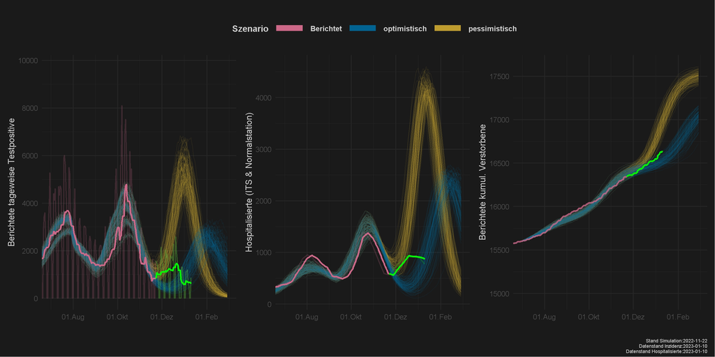

Fig. 11 (updated)

## Update on the 2022/23 influenza-wave in Germany:

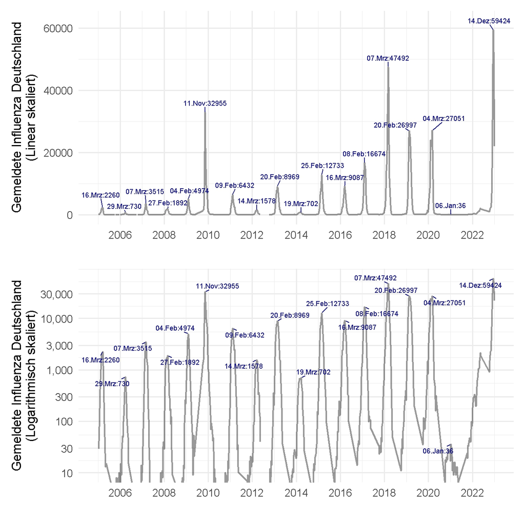

Datasource: https://survstat.rki.de/